This report uses data for all congressional districts represented in the U.S House of Representatives during the 115th U.S Congress. There are 5 variables for this data and this report is about which variable(s) is/are the best identifier for predicting the party for each district. The variables on this data will be explained thoroghly in the “Data” section of this report.

115th U.S Congress is the most up to date meeting of the legislative branch of U.S federal government. It is composed of Senate and the House of Representatives and meets in Washington, D.C[^1]. The House of Representatives incase two political parties, Democratic and Republican; Currently, Republicans are dominating over the Democratic party in numbers. There are 436 congressional districts and some states have more districts than others.

| Variable Name | Description | Summary |
| --- | --- | --- |
| state | the U.S. state containing the district, or the District of Columbia | 51 States. California has the most districts. |
| district | an identifier of Congressional district within state | Total 436 districts. |
| electedrep | name of person elected to the 115th Congress | 436 unique individuals for each district |
| party | the party affiliation of the Representative during the 115th Congress:,D for Democrat, R for Republican | There are 195 Democrat and 241 Republican party districts. |
| medHouseIncome | median household income (dollars) | Min: 29234 (New York) Median: 56076 Max: 125790 (California) Mean: 60090 |

- Mean median house income for Republican district: 58402.96
- Mean median house income for Democrat district: 62174.67
- State that has highest median house income: California
- State that has the lowest median house income: New York
- 39 districts in California is from Democrat
- 25 districts in Texas is from Republican

Since the median house income between Republican and Democrat is different, one could hypothesize that medHouseIncome could be the feature that could be used to predict party in this dataset. Also, some states prefers one party over another. For example, 39 districts in California is from the Democrat. However, state like New York which prefers democrats(18/27) has the lowest medHouseIncome. Hence one could make argument that there could be state related random effect acting on this dataset.

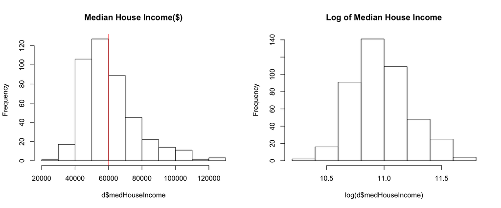

- From the histogram, Median House Income has a skew hence log scale was used to normalize the data.
- Red vertical line indicates the Mean of Median House Income. Since it is larger than the Median of Median House Income and tail is trailing off from the right side, the distribution is skewed right and non normal.
- For this model, only the variable MedHouseIncome was used for the linear portion of the model.

```
model{
    for(i in 1: length(party)){
        party[i] ~ dbern(prob[i])
        logit(prob[i]) <- beta0 + betaMedHouseIncome*MedHouseIncome_scaled[i]
        party_rep[i] ~ dbern(prob[i])
    }
    beta0 ~ dt(0, 1/10^2, 1)
    betaMedHouseIncome ~ dt(0, 1/2.5^2, 1)
}
```

- Number of chains: 4 chains were used,
- Overdispersed Initial values
  - $\beta_{0}$(intercept):(10, -10, 20, -20)
  - $\beta_{MedHouseIncome}$(slope): (10, -10)
- Length of Burn-in: 1000
- Number of iterations used per chain: 4000
- Thinning: Not used
- Effective sample size:
  - $\beta_{MedHouseIncome}$ = $9782.2707458$
  - $\beta_{0}$ = $9780.1955994$
  - Since they are more 400, they are adequate.
- Convergence:
  - From Gelman-Rubin statistics, observed that R < 1.1
- Posterior Mean:
  - $\beta_{MedHouseIncome}$ = $0.3605287$
  - $\beta_{0}$ = $-0.2126306$
- Posterior SD:
  - $\beta_{MedHouseIncome}$ = $0.1957307$
  - $\beta_{0}$ = $0.0961756$
- 95% central posterior interval:

  |  | Slope | B_0 |
  | --- | --- | --- |
  | 2.5% | -0.0130127 | -0.3992323 |
  | 97.5% | 0.7471129 | -0.0233016 |

- Posterior Probability that slope($\beta_{MedHouseIncome}$) exceeds Zero = $97.01875$%
- Bayes Factor = 32.5429769
- Penalized Deviance(Plummer’s): 600
- Penalty(effective number of parameters): 1.942

```
model{
    for (i in 1:length(party)) {
        party[i] ~ dbern(prob[i])
        logit(prob[i]) <-
            beta_0 + betaMedHouseIncome * MedHouseIncome_scaled[i] + epsilon[state[i]]
        party_rep[i] ~ dbern(prob[i])
    }

    beta_0 ~ dt(0, 1 / 10 ^ 2, 1)
    betaMedHouseIncome ~ dt(0, 1 / 2.5 ^ 2, 1)

    for (j in 1:max(state)){
        epsilon[j] ~ dnorm(0, 1/sigmaState^2)
    }

    sigmaState ~ dunif(0, 10)
}
```

- Number of chains: 4 chains were used
- Overdispersed Initial values
  - $\beta_{0}$(intercept):(10, -10, 20, -20)
  - $\beta_{MedHouseIncome}$(slope): (10, -10)
- Length of Burn-in: 1000
- Number of iterations used per chain: 4000
- Thinning: Not used
- Effective sample size:
  - $\beta_{MedHouseIncome}$ = $2426.7222675$
  - $\beta_{0}$ = $965.0715742$
  - Minimum random error = $1754.9600701$
  - Since they are more 400, they are adequate.
- Convergence:
  - From Gelman-Rubin statistics, observed that R < 1.1 (1.02)
- Posterior Mean:
  - $\beta_{MedHouseIncome}$ = $-0.5567995$
  - $\beta_{0}$ = $-0.4691646$
- Posterior SD:
  - $\beta_{MedHouseIncome}$ = $0.2788947$
  - $\beta_{0}$ = $0.2591862$
- 95% central posterior interval:

  |  | Slope | B_0 |
  | --- | --- | --- |
  | 2.5% | -1.1126697 | -0.9862484 |
  | 97.5% | -0.0207576 | 0.0375969 |

- Posterior Probability that slope($\beta_{MedHouseIncome}$) exceeds Zero = $2.175$% however it is very small(less than 5%) hence conclusion can be drawn that slope is negative.
- Bayes Factor = 0.0222336
- State that has the largest posterior mean random effect($2.7217918$): Massachusetts
- State that has the lowest posterior mean random effect($-1.6480655$): Oklahoma
- This means that most of the districts of Massachusetts probably voted for Democrats where most of the districts of Oklahoma voted for Republican.
- Even if the slope is negative and intercept is negative, having positive random effects will make Massachusetts vote democrats
- Penalized Deviance(Plummer’s): 538.8
- Penalty(effective number of parameters): 34.21
- Second model has slightly smaller Plummer’s DIC than first. Hence second model is better.

In this report, Bayesian logistic regression model was used to explain party based on the natural log of medHouseIncome for model 1. The first model was converged after 1000 burn in and 4000 iterations. The effective size was adequate. From the posterior mean of the $\beta_{MedianHouseIncome}$, it is apparent that as median house Income increases, the probability that they will vote Democrats increased. They had positive relationship. However, as mentioned in the data section, state like New York which voted towards Democrats had the lowest median house income. Hence, we revised the first model to include random effect term that varies by state. The second model was also converged after 1000 burn in and 4000 iterations. The effective size was adequate. However the posterior probability that the $\beta_{MedianHouseIncome}$ exceeds zero was less than 5%. Therefore as median Income grows, in this case, the probability of electing a Democrat decreases yet having positive random effect term shows that it reduces the negative slope effect. Comparing both models’ Plummer’s DIC, second model had lower DIC therefore, there could be a random effect due to State that affects the voter’s decision.

```r
knitr::opts_chunk$set(echo = FALSE,
                      warning = FALSE,
                      message = FALSE,
                      cache = FALSE,
                      fig.align = "center"
                      )
library(knitr)
library(rjags)
d = read.csv('party115cong.csv')

##########  Basic Exploratory Data Analysis ###########
nrow(d) # total 436 districts

nrow(d[d$party=='R',])   # 241 Republican district
nrow(d[d$party=='D',])   # 195 Democrat district
r = d[d$party=='R',]     # selecting the data for Republican only
dem = d[d$party=='D',]   # selecting the data for Democrats only
mean(r$medHouseIncome)   # mean republican party house income
mean(dem$medHouseIncome) # mean democrat party house income

data.frame(table(r$state))   # Republican has 25 district in Texas
data.frame(table(dem$state)) # Democrat has 39 district in California

d[d$medHouseIncome==max(d$medHouseIncome),] # California has the highest median House Income = 125790
d[d$medHouseIncome==min(d$medHouseIncome),] # New York has the lowest median House Income = 29234

summary(d) # Just a quick summary of the variables in this data
##########  Basic Exploratory Data Analysis END ###########

########## Histogram of medHouseIncome variable ##########

par(mfrow=c(1, 2))  # two histogram side by side for comparison

hist(d$medHouseIncome, main='Median House Income($)') # Histogram of the medHouseIncome
abline(v=60090, col="red")                            # Red vertical line indicates the Mean of the medHouseIncome
hist(log(d$medHouseIncome), main='Log of Median House Income') # Histogram of the log of medHouseIncome

########## Histogram of medHouseIncome variable END ##########
model{
    for(i in 1: length(party)){
        party[i] ~ dbern(prob[i])
        logit(prob[i]) <- beta0 + betaMedHouseIncome*MedHouseIncome_scaled[i]
        party_rep[i] ~ dbern(prob[i])
    }
    beta0 ~ dt(0, 1/10^2, 1)
    betaMedHouseIncome ~ dt(0, 1/2.5^2, 1)
}

###### 1.(b) Summarization of the details of computation ######

cat_to_num = function(cat) {
# This function creates numerical value from the party category.   If 'R', then returns 0 and 'D' then returns 1. This works well with apply function.
    if (cat == 'R') {
        return(0)
    }
    return(1)
}

# Add additional column party_i that indicates the party in numeric. if R, 0, if D, 1.
d$party_i = lapply(d$party, cat_to_num)

# values used for the variable.
# scale was done after taking the log.
# scale to have sample SD of 0.5
d1 = list(party = d$party_i,
          MedHouseIncome_scaled = as.vector(scale(log(d$medHouseIncome), scale =
          2 * sd(log(d$medHouseIncome)))))

# Initializing parameters in overdispersed way
inits1 = list(
    list(beta0=c(10), betaMedHouseIncome=(10)),
    list(beta0=c(-10), betaMedHouseIncome=(-10)),
    list(beta0=c(-20), betaMedHouseIncome=(10)),
    list(beta0=c(20), betaMedHouseIncome=(-10))
)

# building the JAGS model
# 4 chains used.
# quiet parameter is used to not display the results
m1 = jags.model('model1.bug', d1, inits1, n.chains=4, n.adapt=1000, quiet = TRUE)

# burn-in of 1000
update(m1, 1000)

# coda samples creation
# used 4000 iterations
x1 <- coda.samples(m1, c("beta0","betaMedHouseIncome"), n.iter=4000)

# Gelman diagnostics to see convergence
gelman.diag(x1, autoburnin=FALSE)

# Effective sample size
effectiveSize(x1)

###### 1.(b) Summarization of the details of computation END ######


###### 1.(c) Posterior Mean, SD and interval ######
# summary of x1 to get posterior statistics
s1 = summary(x1)

# Statistics to get the stats['betaMedHouseIncome','Mean']
# Actual values are used in inline variable r code.
stats = s1$statistics

# Quantiles
quantiles = s1$quantiles
slope_q = quantiles['betaMedHouseIncome', c(1, 5)]
int_q = quantiles['beta0', c(1, 5)]

# making a new data frame for the 95% quantile
t1 = data.frame(betaMedHouseIncome=slope_q, beta0=int_q )
# kable(t1, col.names=c("Slope","intercept"))

###### 1.(c) Posterior Mean, SD and interval END ######

###### 1.(d) Approximation of the posterior probability that the “slope” exceeds zero ######

#Getting the posterior using matrix
x1_mat = as.matrix(x1)

# Posterior probability that is bigger than 0
post.prob.1 = mean(x1_mat[,'betaMedHouseIncome'] > 0)

# Bayes Factor calculation
b.factor.1 = mean(x1_mat[,'betaMedHouseIncome'] > 0) / mean(x1_mat[,'betaMedHouseIncome'] < 0)

###### 1.(d) Approximation of the posterior probability that the “slope” exceeds zero END ######

##### 1.(e) Approximation of the value of (Plummer’s) DIC and the associated effective number ######

# DIC and effective number
dic_1 = dic.samples(m1, 1000)

###### 1.(e) Approximation of the value of (Plummer’s) DIC and the associated effective number END ######
model{
    for (i in 1:length(party)) {
        party[i] ~ dbern(prob[i])
        logit(prob[i]) <-
            beta_0 + betaMedHouseIncome * MedHouseIncome_scaled[i] + epsilon[state[i]]
        party_rep[i] ~ dbern(prob[i])
    }

    beta_0 ~ dt(0, 1 / 10 ^ 2, 1)
    betaMedHouseIncome ~ dt(0, 1 / 2.5 ^ 2, 1)

    for (j in 1:max(state)){
        epsilon[j] ~ dnorm(0, 1/sigmaState^2)
    }

    sigmaState ~ dunif(0, 10)
}

###### 2.(b) Summarization of the details of computation ######

# Creating index for state and made another column in the original data frame as state_i
d$state_i = unclass(d$state)

# List of values used
d2 = list(
    party = d$party_i,
    MedHouseIncome_scaled = as.vector(scale(log(d$medHouseIncome), scale =
    2 * sd(
    log(d$medHouseIncome)
    ))),
    state = d$state_i
    )

# verdispersed parameters initialization
inits2 = list(
    list(beta_0 = c(10), betaMedHouseIncome = (10), sigmaState= 0.1),
    list(beta_0 = c(-10), betaMedHouseIncome = (-10), sigmaState=10),
    list(beta_0 = c(-20), betaMedHouseIncome = (10), sigmaState=10),
    list(beta_0 = c(20), betaMedHouseIncome = (-10), sigmaState=0.1)
)

# making the JAGS model with 4 chains
m2 = jags.model('model2.bug', d2, inits2, n.chains=4, n.adapt=1000, quiet = TRUE)

# burn in of 1000
update(m2, 1000)

# making coda samples with 4000 iterations
x2 <- coda.samples(m2, c("beta_0","betaMedHouseIncome", "epsilon"), n.iter=4000)

# Gelman diagnostics for convergence
gelman.diag(x2, autoburnin=FALSE)

# Effective sample size
effectiveSize(x2)

###### 2.(b) Summarization of the details of computation END ######

###### 2.(c) Posterior Mean, SD and interval ######

# summary of x2 to get posterior statistics
s2 = summary(x2)

# Statistics to get the stats2['betaMedHouseIncome','Mean']
# Actual values are used in inline variable r code.
stats2 = s2$statistics

# Quantiles
quantiles2 = s2$quantiles
slope_q2 = quantiles2['betaMedHouseIncome', c(1, 5)]
int_q2 = quantiles2['beta_0', c(1, 5)]

# making a new data frame for the 95% quantile
t2 = data.frame(betaMedHouseIncome=slope_q2, beta0=int_q2)
###### 2.(c) Posterior Mean, SD and interval END ######

###### 2.(d) Approximation of the posterior probability that the “slope” exceeds zero ######

# posterior matrix
x2_mat = as.matrix(x2)

# posterior probability that exceeds zero
post.prob.2 = mean(x2_mat[,'betaMedHouseIncome'] > 0)

# Bayes factor
b.factor.2 = mean(x2_mat[,'betaMedHouseIncome'] > 0) / mean(x2_mat[,'betaMedHouseIncome'] < 0)
###### 2.(d) Approximation of the posterior probability that the “slope” exceeds zero END ######

###### (e) Posterior mean random effect ######

max_index = which.max(stats2[3:53]) # returns the index of max posterior mean random effect
min_index = which.min(stats2[3:53]) # returns the index of min posterior mean random effect
# returns the max and min posterior mean random effect
states_re_max_min = unique(d[d$state_i==max_index|d$state_i==min_index, ]$state)

# outputs original data with max and min index
# d[d$state_i == max_index, ]
# d[d$state_i == min_index, ]


# max_state_mean_mhi = mean(d[d$state_i == max_index, ]$medHouseIncome)
# min_state_mean_mhi = mean(d[d$state_i == min_index, ]$medHouseIncome)

# Function to perform ilogit
ilogit <- function(x) 1/(1+exp(-x))


# stats2['betaMedHouseIncome','Mean'] * log(max_state_mean_mhi) + stats2['beta_0','Mean'])
#
# inv.logit(stats2['betaMedHouseIncome','Mean'] * log(min_state_mean_mhi) + stats2['beta_0','Mean'])

###### (e) Posterior mean random effect END ######

###### Approximation of the value of (Plummer’s) DIC and the associated effective number ######

# DIC calculation
dic_2 = dic.samples(m2, 1000)

###### Approximation of the value of (Plummer’s) DIC and the associated effective number END ######
```

[^1]: Wikipedia contributors, “115th United States Congress,” Wikipedia, The Free Encyclopedia, https://en.wikipedia.org/w/index.php?title=115th_United_States_Congress&oldid=873183244 (accessed December 13, 2018).